# Lab_2

Мелихова И.С.

28 02 2020

Лабораторная работа 2

Графические системы в R: пакеты base, lattice, ggplot2

Задача:

Построить коробчатые диаграммы суммарной массы поставок в сентябре-декабре по годам (пропуски, заменённые на модельные значения, Netweight.kg.model). Цветом показать четыре группы стран-поставщиков: США, страны латинской америки, страны ЕС и все остальные.

Данные: импорт сливочного масла в РФ.

Загружаем библиотеки.

```r
library('data.table')          # работаем с объектами "таблица данных"
library('moments')             # коэффициенты асимметрии и эксцесса
library('lattice')
library('ggplot2')
library('dplyr')
```

загружаем файл с данными по импорту масла в РФ.

```r
fileURL <- 'https://raw.githubusercontent.com/aksyuk/R-data/master/COMTRADE/040510-Imp-RF-comtrade.csv'
# создаём директорию для данных, если она ещё не существует:
if (!file.exists('./data')) {
  dir.create('./data')
}
# создаём файл с логом загрузок, если он ещё не существует:
if (!file.exists('./data/download.log')) {
  file.create('./data/download.log')
}
# загружаем файл, если он ещё не существует,
#  и делаем запись о загрузке в лог:
if (!file.exists('./data/040510-Imp-RF-comtrade.csv')) {
  download.file(fileURL, './data/040510-Imp-RF-comtrade.csv')
  # сделать запись в лог
  write(paste('Файл "040510-Imp-RF-comtrade.csv" загружен', Sys.time()),
        file = './data/download.log', append = T)
}
# читаем данные из загруженного .csv во фрейм, если он ещё не существует
if (!exists('DT.import')){
  DT.import <- data.table(read.csv('./data/040510-Imp-RF-comtrade.csv',
                                   stringsAsFactors = F))
}
# предварительный просмотр
DT.import <- DT.import[1:215]
```

Предварительный просмотр.

```r
dim(DT.import)            # размерность таблицы
```

```
## [1] 215  17
```

```r
str(DT.import)            # структура (характеристики столбцов)
```

```
## Classes 'data.table' and 'data.frame':   215 obs. of  17 variables:
##  $ Classification : chr  "HS" "HS" "HS" "HS" ...
##  $ Year           : int  2010 2010 2010 2010 2010 2010 2010 2010 2010 2010 ...
##  $ Period         : int  201008 201001 201002 201007 201007 201009 201001 201002 201001 201002 ...
##  $ Period.Desc    : chr  "August 2010" "January 2010" "February 2010" "July 2010" ...
##  $ Aggregate.Level: int  6 6 6 6 6 6 6 6 6 6 ...
##  $ Is.Leaf.Code   : int  1 1 1 1 1 1 1 1 1 1 ...
##  $ Trade.Flow.Code: int  1 1 1 1 1 1 1 1 1 1 ...
##  $ Trade.Flow     : chr  "Imports" "Imports" "Imports" "Imports" ...
##  $ Reporter.Code  : int  51 97 97 97 246 268 276 276 398 398 ...
##  $ Reporter       : chr  "Armenia" "EU-28" "EU-28" "EU-28" ...
##  $ Partner.Code   : int  643 643 643 643 643 643 643 643 643 643 ...
##  $ Partner        : chr  "Russian Federation" "Russian Federation" "Russian Federation" "Russian Federation" ...
##  $ Commodity.Code : int  40510 40510 40510 40510 40510 40510 40510 40510 40510 40510 ...
##  $ Commodity      : chr  "Dairy produce; derived from milk, butter" "Dairy produce; derived from milk, butter" "Dairy produce; derived from milk, butter" "Dairy produce; derived from milk, butter" ...
##  $ Netweight.kg   : int  200 12 120 57600 38400 10000 12 120 9759 10204 ...
##  $ Trade.Value.USD: int  1170 68 502 302318 201551 55926 68 502 40001 39552 ...
##  $ Flag           : int  0 0 0 0 0 0 0 0 0 0 ...
##  - attr(*, ".internal.selfref")=<externalptr>
```

```r
DT.import          # удобный просмотр объекта data.table
```

```
##      Classification Year Period   Period.Desc Aggregate.Level Is.Leaf.Code
##   1:             HS 2010 201008   August 2010               6            1
##   2:             HS 2010 201001  January 2010               6            1
##   3:             HS 2010 201002 February 2010               6            1
##   4:             HS 2010 201007     July 2010               6            1
##   5:             HS 2010 201007     July 2010               6            1
##  ---
## 211:             HS 2014 201410  October 2014               6            1
## 212:             HS 2014 201411 November 2014               6            1
## 213:             HS 2014 201412 December 2014               6            1
## 214:             HS 2014 201408   August 2014               6            1
## 215:             HS 2014 201403    March 2014               6            1
##      Trade.Flow.Code Trade.Flow Reporter.Code   Reporter Partner.Code
##   1:               1    Imports            51    Armenia          643
##   2:               1    Imports            97      EU-28          643
```

[output cut: 33 more lines]

В столбце Period сохраняем только номера месяцев, и выбираем из них: сентябрь, октябрь, ноябрь, декабрь.

```r
DT.import$Period <- (DT.import$Period) %% 100
DT.import <- DT.import[DT.import$Period > 8,]
```

```r
DT.import[Netweight.kg == 0, Netweight.kg := NA]
x <- DT.import$Trade.Value.USD
y <- DT.import$Netweight.kg
fit <- lm(y ~ x)
# y[y == 0] <- NA
# оценка регрессии с помощью
# результаты
summary(fit)
```

```
##
## Call:
## lm(formula = y ~ x)
##
## Residuals:
##    Min     1Q Median     3Q    Max
## -50818  -5203   -474   5225  44693
##
## Coefficients:
##              Estimate Std. Error t value Pr(>|t|)
## (Intercept) 3.026e+02  2.230e+03   0.136    0.892
## x           2.770e-01  9.699e-03  28.557   <2e-16 ***
## ---
## Signif. codes:  0 '***' 0.001 '**' 0.01 '*' 0.05 '.' 0.1 ' ' 1
##
## Residual standard error: 14300 on 68 degrees of freedom
##   (5 observations deleted due to missingness)
## Multiple R-squared:  0.923,  Adjusted R-squared:  0.9219
## F-statistic: 815.5 on 1 and 68 DF,  p-value: < 2.2e-16
```

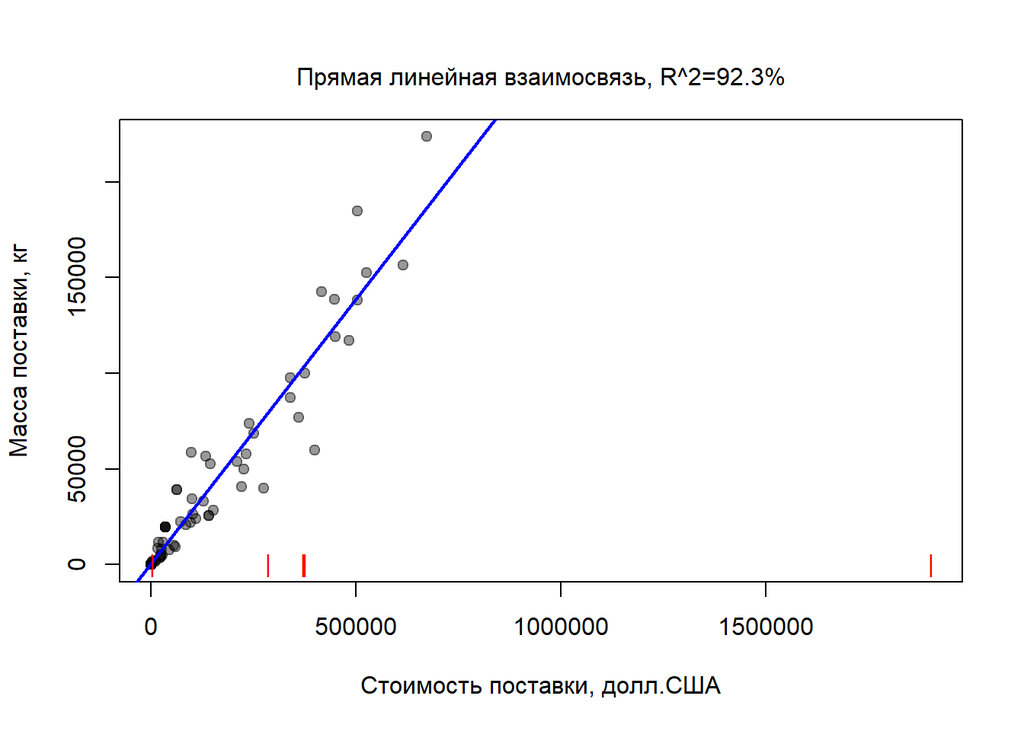

```r
# сохраняем R-квадрат
R.sq <- summary(fit)$r.squared
# график разброса с линией регрессии
# 1. делаем точки прозрачными, чтобы обозначить центр массы
plot(x,
     y,
     xlab = 'Стоимость поставки, долл.США',
     ylab = 'Масса поставки, кг',
     pch = 21,
     col = rgb(0, 0, 0, alpha = 0.4),
     bg = rgb(0, 0, 0, alpha = 0.4))
# 2. добавляем прямую регрессии на график
abline(fit, col = rgb(0, 0, 1), lwd = 2)
# 3. добавляем название графика
mtext(paste('Прямая линейная взаимосвязь, R^2=',
            round(R.sq*100, 1),
            '%', sep = ''),
      side = 3, line = 1)
# координаты пропущенных y по оси x
NAs <- x[is.na(y)]
# 4. отмечаем каким значениям x соответствуют пропущенные y
points(x = NAs,
       y = rep(0, length(NAs)),
       col = 'red', pch = '|')
```

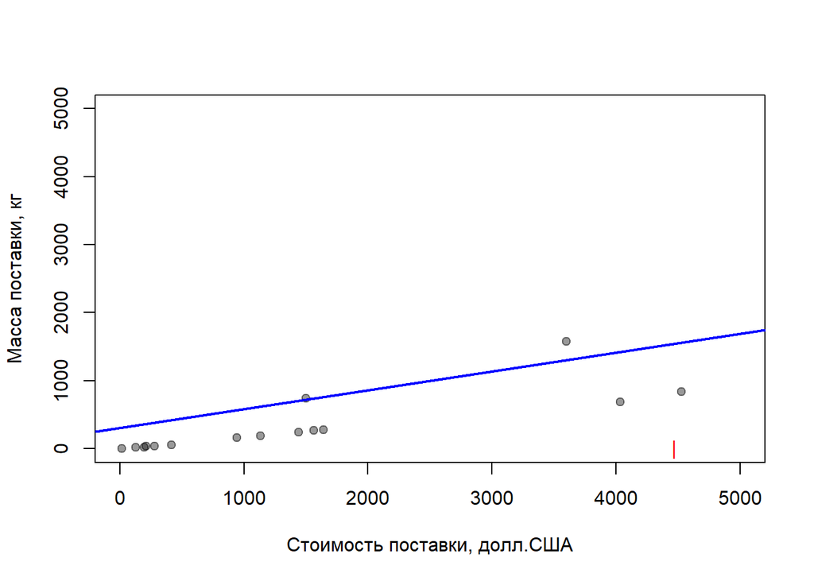

```r
# увеличение участка графика: добавляем xlim, ylim
plot(x,
     y,
     xlim = c(0, 5000),
     ylim = c(0, 5000),
     xlab = 'Стоимость поставки, долл.США',
     ylab = 'Масса поставки, кг',
     pch = 21,
     col = rgb(0, 0, 0, alpha = 0.4),
     bg = rgb(0, 0, 0, alpha = 0.4))
# линия регрессии
abline(fit, col = rgb(0, 0, 1), lwd = 2)
# координаты пропусков по X
points(x = NAs,
       y = rep(0, length(NAs)),
       col = 'red', pch = '|')
```

```r
# пробуем регрессию на логарифмах
fit.log <- lm(log(y)~log(x))
# результаты
summary(fit.log)
```

```
##
## Call:
## lm(formula = log(y) ~ log(x))
##
## Residuals:
##     Min      1Q  Median      3Q     Max
## -0.7902 -0.2834 -0.1151  0.1540  0.9539
##
## Coefficients:
##             Estimate Std. Error t value Pr(>|t|)
## (Intercept) -2.28491    0.23960  -9.536 3.66e-14 ***
## log(x)       1.08538    0.02225  48.771  < 2e-16 ***
## ---
## Signif. codes:  0 '***' 0.001 '**' 0.01 '*' 0.05 '.' 0.1 ' ' 1
##
## Residual standard error: 0.4483 on 68 degrees of freedom
##   (5 observations deleted due to missingness)
## Multiple R-squared:  0.9722, Adjusted R-squared:  0.9718
## F-statistic:  2379 on 1 and 68 DF,  p-value: < 2.2e-16
```

```r
# сохраняем R-квадрат
R.sq.log <- summary(fit.log)$r.squared
```

Попробуем построить модель парной линейной регрессии на логарифмах переменных.Здесь скорректированный R-квадрат выше (0,97). Модель и её параметры значимы. Построим график разброса. Эта модель больше подходит для аппроксимации пропущенных значений.

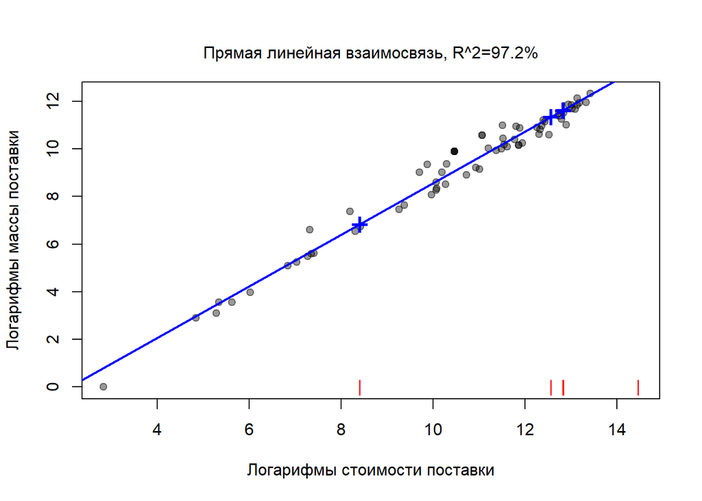

```r
# график разброса с линией регрессии (логарифмы)
# 1. делаем точки прозрачными, чтобы обозначить центр массы
plot(log(x),
     log(y),
     xlab = 'Логарифмы стоимости поставки',
     ylab = 'Логарифмы массы поставки',
     pch = 21,
     col = rgb(0, 0, 0, alpha = 0.4),
     bg = rgb(0, 0, 0, alpha = 0.4))
# 2. добавляем прямую регрессии на график
abline(fit.log, col = rgb(0, 0, 1), lwd = 2)
# 3. добавляем название графика
mtext(paste('Прямая линейная взаимосвязь, R^2=',
            round(R.sq.log*100, 1),
            '%', sep = ''),
      side = 3, line = 1)
# отмечаем каким значениям x соответствуют пропущенные y
points(x = log(NAs),
       y = rep(0, length(NAs)),
       col = 'red', pch = '|')
# новый столбец, в котором будут заполнены пропуски
DT.import[, Netweight.kg.model := Netweight.kg]
# прогноз по модели на логарифмах сохраняем как вектор
y.model.log <- predict(fit.log, newdata = data.frame(x = NAs))
# наносим прогнозы на график
points(log(NAs),
       y.model.log, col = 'blue',
       pch = '+', cex = 2)
```